# Poverty Rates and the Impact of Minimum Wages

Matteo Lieb

12/11/2020

## Introduction

COVID-19 has presented significant global economic challenges, including in the United States. As of early December, 20.16 million Americans received some type of unemployment benefit (Cox, 2020). According to recent analysis, almost 7 million more people have entered poverty from May to October of 2020 (Han, Meyer, & Sullivan, 2020). It is clear that poverty is therefore an especially relevant public policy problem. One solution that advocates and policy makers have often cited is increasing the minimum wage. This report seeks to assess whether a higher state minimum wage rate is associated with lower poverty rates. However, it is important to also consider the many other determinants of poverty within each state. Therefore, this report also aims to assess the importance of these other variables in addition to a state’s minimum wage rate.

This report aims to highlight the policy relevance of poverty in the United States as well as background on this issue and the solution being analyzed, minimum wage policy. Additionally, examples of existing literature on this topic are presented to offer information on previous findings. The use and analysis of quality and meaningful data are critical to the success of this report. Therefore, information on the collection and preparation of the utilized data are shared. This report also offers an in-depth review of the methods that were incorporated into this analysis. Following that review, results are presented that connect to the identified goal. Finally, this report evaluates its success, the methods considered in the project designed but that weren’t used, and the additional analysis that would have been conducted if more time was available.

## Problem Statement and Background:

In June of 2020, just over 25% of non-elderly Americans had household incomes below the Federal Poverty Line (Saenz & Sherman, 2020). This considerable share of people, which includes those of working-age, illustrates the income challenges faced by Americans. The poverty rate, which going forward will be represented as percentage of household incomes who fall below the federal poverty line, has fluctuated over the past several decades. Between 1964 and 2014, the poverty rate ranged between 11.1% and 19% (Chaudry, et al., 2016). It is important to note that existing analysis has found poverty rates to vary with economic cycles, including the Great Recession (Chaudry, et al., 2016). Poverty is an important policy area to analyze given its implications across a broad range of other areas including health, education, and crime. A recent study went as far to identify that women in the bottom of 1% earnings live on average a little over ten years less than women in the top 1% (Chetty, Stepner, & Abraham, 2016). To combat poverty, policymakers have utilized a diverse array of policy solutions with mixed results. In this search, it is important to consider that without access to meaningful income, poverty will continue to present a threat.

Wage stagnation has been a serious economic concern within the United States. While average incomes have risen over the past forty years, when one adjusts purchasing power for inflation it is roughly the same (DeSilver, 2018). This trend is even more concerning when one analyzes low-income earners, whose wages adjusted for inflation fell 5% between 1979 and 2013 (Mishel, Gould, & Bivens, 2015). This stagnation highlights the ongoing income challenges, and in turn risk of poverty, faced by Americans today. Given the scope of this project, it is important to consider existing minimum wage policy. The federal minimum wage has been at $7.25 per hour since 2009, the longest period of time without an increase in the federal minimum wage’s history (Wage and Hour Division, n.d.). However, while the federal government has not changed its minimum wage in over ten years there has been changes to minimum wage policy at the state level (Wage and Hour Division, 2020). This report will offer descriptive statistics for these state minimum wage levels to offer a clearer picture of the current landscape.

This report is not the first to evaluate the relationship between poverty and minimum wage policy. One recent study by Arindrajit Dube found that increases in the minimum wage did result in lower percentages of people below several poverty levels (Dube, 2019). In this study, Dube estimated that if the federal minimum wage increased from $7.25 to $12 per hour, it would lead to a 1.9 percentage point reduction in the poverty rate (Dube, 2019). Another study compared how well minimum wage increases and the Earned Income Tax Credit (EITC) are at reducing poverty (Quinn & Cahill, 2017). It finds that while raising the minimum wage would lift some people out of poverty, it is not as effective a policy solution for reducing poverty as the EITC (Quinn & Cahill, 2017).

## Data:

The data utilized within this report was obtained from two sources. With regards to minimum wage data for states, that data was taken from the Wage and Hour Division at the U.S. Department of Labor. Specifically, it was pulled from a web-page that presented the state non-farm minimum wages from 1968 to 2019 (Wage and Hour Division, 2020). As referenced earlier, this report also included other relevant variables in its analysis for the years 2010 and 2019. Specifically, the 2010 data was pulled from the 1-Year estimates from the 2010 American Community Survey (ACS) (American Community Survey, 2010). Similarly, the 2019 data was pulled from the American Community Survey’s 2019 1-Year estimates (American Community Survey, 2019).

For both data sources, the unit of observation are states for the years 2010 and 2019. The data includes information for all fifty states and the District of Columbia. The ACS offers a broad array of diverse estimators for state level analysis, many of which were not relevant to this study. Therefore, to present the best information for this report the data set was thoroughly evaluated to select the most relevant variables. In this report the dependent variable is a state’s poverty rate, which is represented by the percentage of people within a state who live below the federal poverty line. Additionally, the key independent variable in this report is each state’ minimum wage per hour. With regards to controls, this report included variables that presented information on the education level within a state, transportation information, housing costs, and more. More specifically, these variables include median age of a state, percent of people within a state over the age of 25 who did not complete a high school diploma, average household size, the state unemployment rate, and percentage of people within a state who use public transportation.

The data was collected from the two referenced sources and therefore needed to be cleaned and combined. As previously discussed, the ACS variables were preselected in the United States Census Bureau’s system and downloaded as a csv file. The minimum wage data on the other hand was web-scrapped from the U.S. Department of Labor’s website. This was done after checking to ensure this was not in violation of their website protocols. Following these processes, all three data sets (minimum wage data, 2010 ACS data, and 2019 ACS data) were uploaded to R for wrangling. With regards to the ACS datasets, they went through several processes to ensure they were ready for evaluation. The variables were renamed for easier interpretation. Given that many of the variables were percentages, they needed to have the percentage sign removed. Lastly, many of the variables were formatted as character variables and therefore needed to be changed to numeric. With regards to the minimum wage data, it also needed to go through several processes. Several non-state observations, including Guam, were removed from the dataset. The variables were once again renamed for better interpretation. States that do not have a minimum wage had the value of the federal minimum wage ($7.25 per hour) filled in. This is due to those states needing to follow the federal minimum wage given their lack of a state minimum wage. Similarly, states that had a minimum wage that was lower than the federal minimum wage went through the same process. Additionally, states that had a minimum wage range were altered to present just the lower end of the range. Finally, there were some observations that had non-numeric characters which were removed to prevent issues with analysis.

## Analysis:

Following the data collection and wrangling processes, this report utilized this data to conduct analysis on the relationship between minimum wage policy and the percentage of people living below the poverty line. However, to understand the geographic distribution for certain variables, this report used geospatial data visualizations to represent that information. Specifically, this report plotted the data from the poverty rate and minimum wage variables on a map of the United States with each state reflecting its value for that variable. Additionally, this report used other data visualization techniques to represent key information.

To create a model that could predict poverty rates and establish the importance of each variable in making that prediction, this report underwent a series of analytical steps. Prior to conducting any analysis, the data needed to be split into training and test data sets. This is done in order that the created model can make accurate predictions and reduce overfitting the data. In this case, the training data represented 75 percent and the test data represented 25 percent of the total data. The report then assessed and plotted the training data to establish how the variables were distributed. In order to transform the data, both now and in the future, this report created a recipe. In this case, the recipe had two fundamental components; it standardized the scale from zero to one and logged the “Median Income” variable to improve analysis. Following the creation of this recipe, the report went ahead and baked both the training and test data to implement those transformations. In a final step before running any models, this report used k-fold cross-validation to try and accurately represent the test error estimates.

These steps are critical to being able to produce meaningful models. This report developed four models to predict a state’s percentage of people living below the poverty line using its minimum wage and other included variables. These are a linear model, a k-nearest neighbors model, a decision tree model, and a random forest model. Each of these models offers their own strengths and weaknesses. For example, while a linear model may not fit the data particularly well, it is easy to interpret. On the other hand, the random forest model may be a much better predictor, however, it is much more challenging to interpret. Following the creation of these models, this report compared them to determine which one had the lowest root mean-squared error (RMSE).

Upon selecting the model with the lowest RMSE, this report created a variable importance plot to determine which of the variables was the most relevant in predicting poverty rates. Upon identifying those important variables, this report created partial dependence (PDP) and individual conditional expectation (ICE) plots to have a better understanding of how select variables were related to poverty rates. After having a better understanding of which variables were important in predicting poverty rates, a model of the same type but with those selected variables and the state’s minimum wage was created. Finally, this report utilized a global surrogate model to allow for model interpretation.

## Results:

This report utilized the analysis referenced above to determine what role a state’s minimum wage played on predicting the percentage of people living below the poverty line within that state. It is important to first analyze the descriptive information about this report’s variables of interest. Figure 1 displays the difference between state poverty rates in 2019 as compared to 2010.

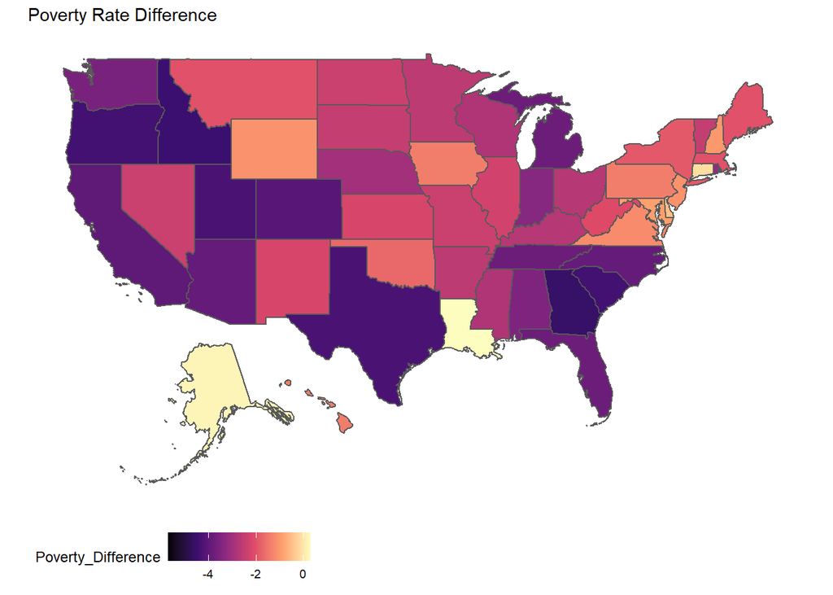

Figure 1: Difference in Poverty Rates between 2010 and 2019

This map shows that most states saw a reduction in their poverty rates. As discussed earlier, poverty rates are associated with economic cycles (Chaudry, et al., 2016). It is therefore possible that these reduced poverty rates are a sign of the economic recovery from the Great Recession. Figure 2 reflects the state minimum wage rate in 2019.

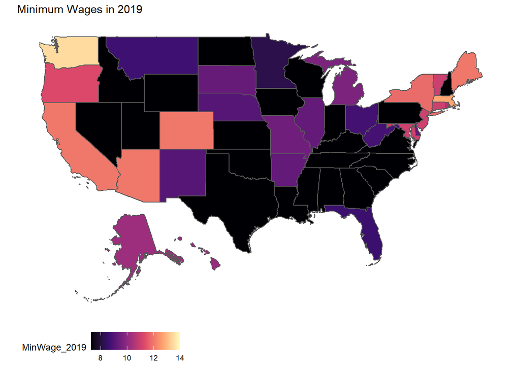

Figure 2: 2019 Minimum Wage Map

This map shows the range of minimum wage rates across the country. One trend that can be observed is that generally there seem to be higher minimum wage rates within states on either coast. Another observation is the volume of states whose effective minimum wage is $7.25 per hour. The map reflects that many of these states fall within the southern part of the United States. Figure 3 highlights each minimum wage rate in a bar plot format.

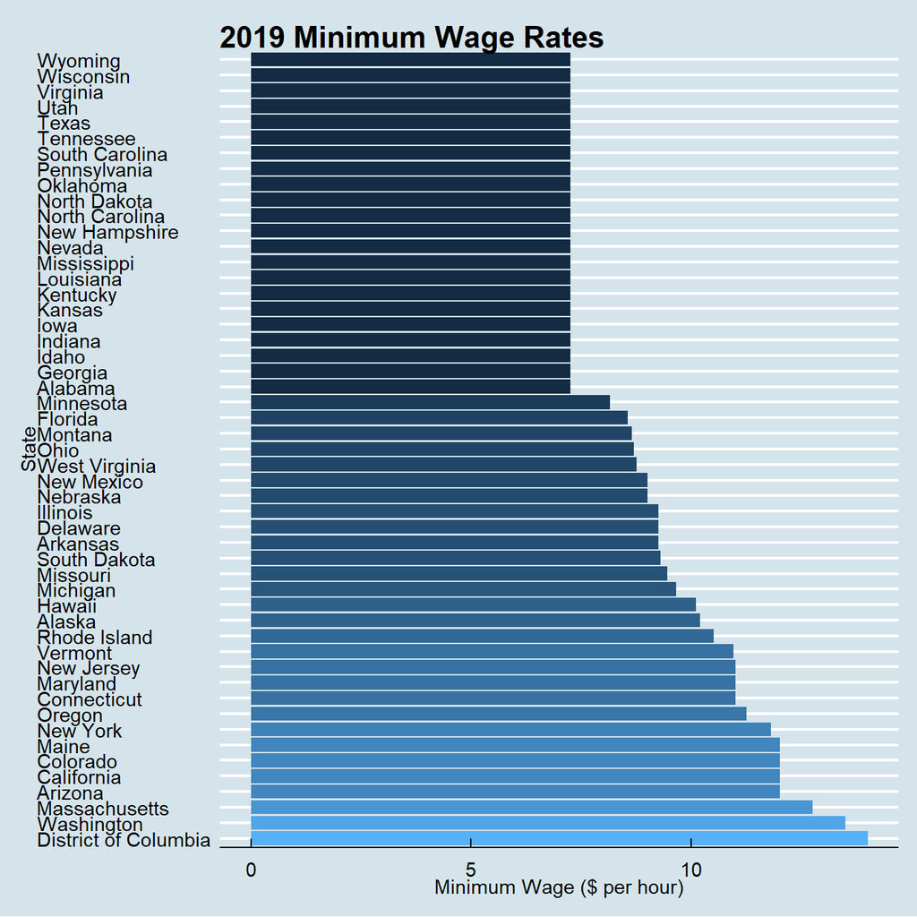

Figure 3: 2019 State Minimum Wage Rates

This plot is in descending order with the states with the lowest minimum wages first. One insight this plot offers is that states that have minimum wages higher than the federal rate are not uniform in their rates. There are states like Montana that are slightly over the federal minimum wage rate, and states that go all the way up to somewhere like the District of Columbia that has a minimum wage rate in 2019 that is almost double the federal minimum wage rate.

After running the four models referenced earlier, this report determined which model was the best fit. A plot was created (Figure 4) that indicates the RMSE for each model with a 95% confidence level.

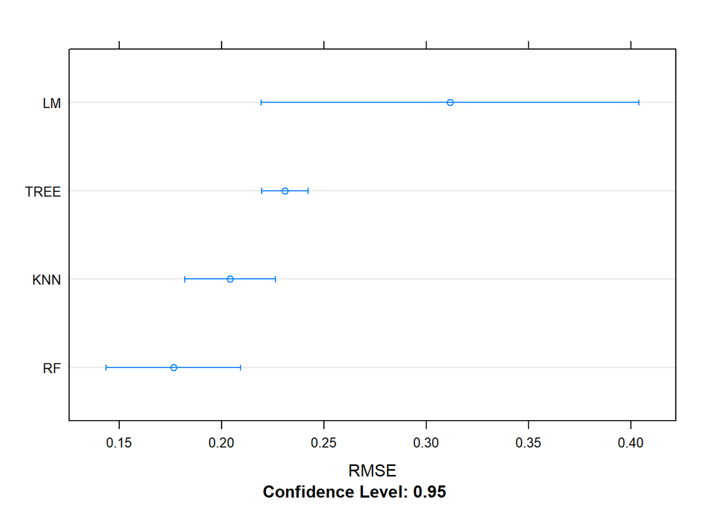

Figure 4: RMSE across Models

It found that the random forest model had the lowest RMSE, with a value of 0.176, of the four models and was therefore the best fit. Following that analysis, a variable importance plot was created (Figure 5).

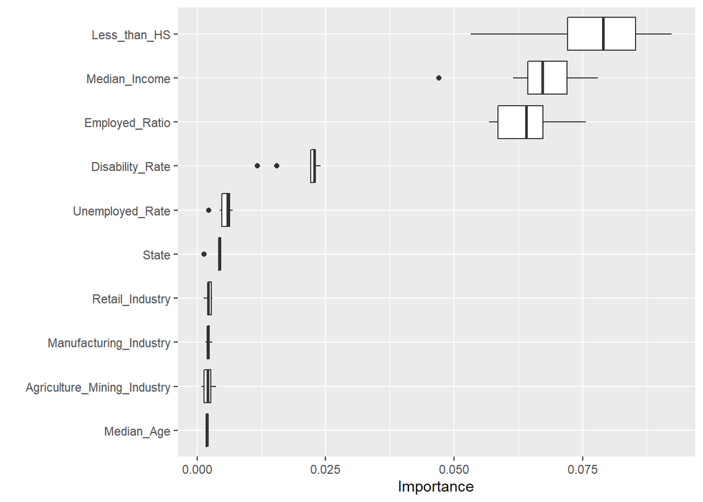

Figure 5: Variable Importance Plot

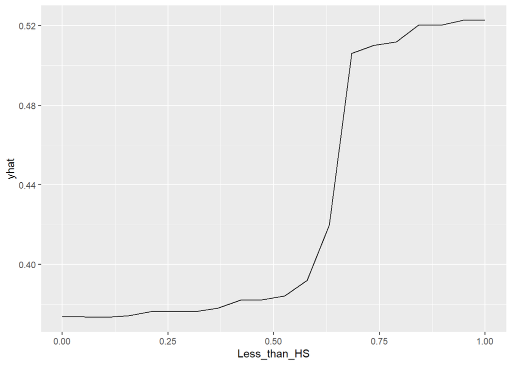

Figure 6: PDP for Lack of High School Attainment

This relationship was confirmed when analyzing the ICE plot for high school attainment (Figure 7).

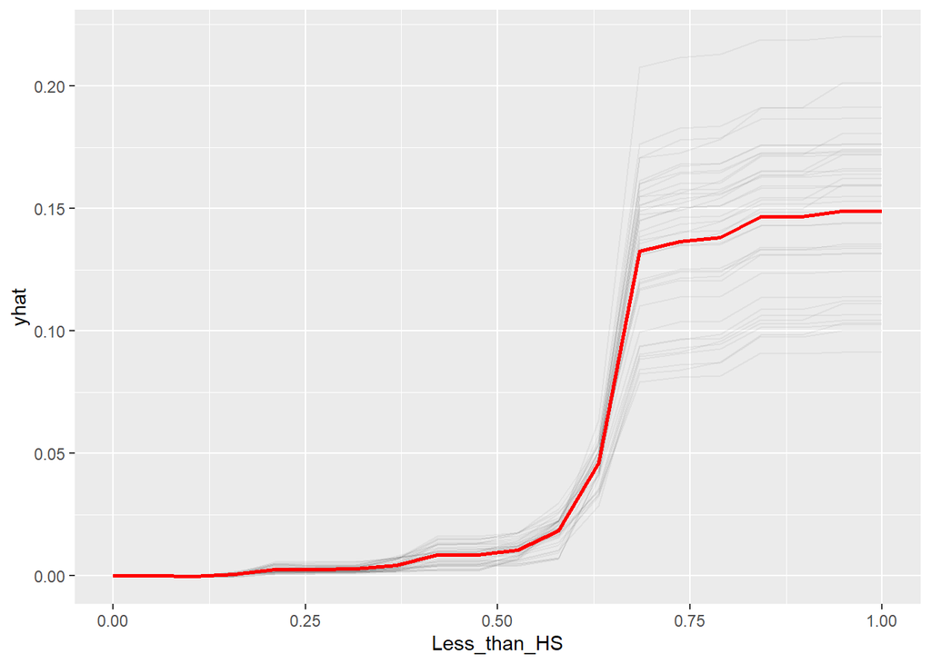

Figure 7: ICE Plot for Lack of High School Attainment

Finally, after creating a global surrogate model with select variables, this report was able to interpret the impact of minimum wage rates in this model. Prior to analyzing it, it is important to note it presented a fairly high r-squared value which was just above 0.8. It showed that states that have higher rates of people over the age of twenty-five without a high school diploma, it is associated with higher poverty rates (Figure 8).

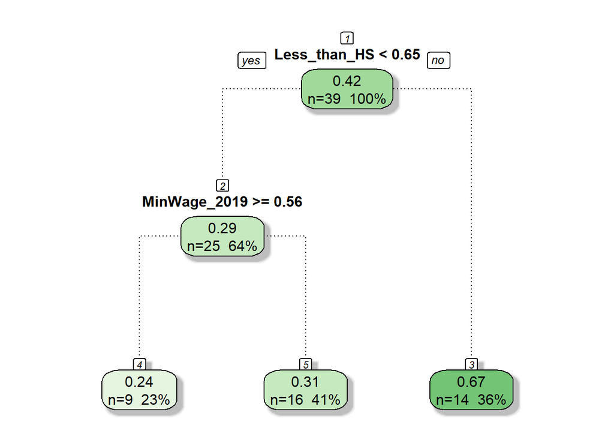

Figure 8: Global Surrogate Model

## Discussion:

This project set out to determine whether there was a relationship between a state’s minimum wage rate and the percentage of people within that state living below the poverty line. This report found that a state’s minimum wage rate was not an important predictor of a state’s poverty rate. Even though it was not an important predictor, it did find that higher minimum wage levels in some situations predict lower poverty rates. This finding therefore does demonstrate some level of success. However, the report did find that several variables when used in the model were relevant at predicting a state’s poverty rate. As discussed earlier, a state’s high school attainment rates, median income, and employed rates were all important in predicting poverty rates. This does demonstrate some level of success from this report as policymakers can use this information in poverty reduction policy design. Poverty is a complex policy problem and this report clearly shows that the variety of factors that can predict the poverty rate within a state.

This report did consider using other methods in this analysis. One in particular would have been the use of interactions among variables. Specifically, representing that interaction through a PDP. In this report there are several variables that may have presented interactions, including median income and the percentage of people over the age of twenty-five who attained a high school diploma. If given more time, there are several processes that would have been expanded to improve this report. This report would have included data from more years as opposed to developing a model just from 2019 data. This would have offered a great amount of information as to the potential impact of minimum wage level on poverty rates. Similarly, this report would have included additional variables to improve the model. One variable in particular that would have been beneficial for analysis is the percentage of people within a state who are paid the minimum wage. Lastly, if given more time this report would have transformed the variables in a way that produced results that are more meaningful to interpret. This would have allowed for great impact on future policy development. Overall, this report achieved some level of success in analyzing the impact of state minimum wages on poverty rates, however, it clearly presents the need for greater analysis on this topic.

Word Count: 2965